# Predict survival on the Titanic

## data explore and preprocessing

```python
import pandas as pd
import numpy as np
import matplotlib.pylab as plt
import seaborn as sns
sns.set_style("whitegrid")
sns.set_context("talk")

%matplotlib inline
```

VARIABLE DESCRIPTIONS:

| Variable Name | Description |
| --- | --- |
| Survived | Survived (1) or died (0) |
| Pclass | Passenger’s class (1 = 1st; 2 = 2nd; 3 = 3rd) |
| Name | Passenger’s name |
| Sex | Passenger’s sex |
| Age | Passenger’s age |
| SibSp | Number of siblings/spouses aboard |
| Parch | Number of parents/children aboard |
| Ticket | Ticket number |
| Fare | Fare |
| Cabin | Cabin |
| Embarked | Port of embarkation (C = Cherbourg; Q = Queenstown; S = Southampton) |

SPECIAL NOTES:

- Pclass is a proxy for socio-economic status (SES)
- 1st ~ Upper; 2nd ~ Middle; 3rd ~ Lower
- Age is in Years; Fractional if Age less than One (1)
- If the Age is Estimated, it is in the form xx.5

With respect to the family relation variables (i.e. sibsp and parch) some relations were ignored. The following are the definitions used for sibsp and parch.

- Sibling: Brother, Sister, Stepbrother, or Stepsister of Passenger Aboard Titanic
- Spouse: Husband or Wife of Passenger Aboard Titanic (Mistresses and Fiances Ignored)
- Parent: Mother or Father of Passenger Aboard Titanic
- Child: Son, Daughter, Stepson, or Stepdaughter of Passenger Aboard Titanic

Other family relatives excluded from this study include cousins,nephews/nieces, aunts/uncles, and in-laws. Some children travelled only with a nanny, therefore parch=0 for them. As well, some travelled with very close friends or neighbors in a village, however, the definitions do not support such relations.

```python
train = pd.read_csv("../data/train.csv")
test = pd.read_csv("../data/test.csv")
```

```python
total = pd.concat([train,test])
total.reset_index(drop=True,inplace=True)
total.info()
```

```
<class 'pandas.core.frame.DataFrame'>
RangeIndex: 1309 entries, 0 to 1308
Data columns (total 12 columns):
Age            1046 non-null float64
Cabin          295 non-null object
Embarked       1307 non-null object
Fare           1308 non-null float64
Name           1309 non-null object
Parch          1309 non-null int64
PassengerId    1309 non-null int64
Pclass         1309 non-null int64
Sex            1309 non-null object
SibSp          1309 non-null int64
Survived       891 non-null float64
Ticket         1309 non-null object
dtypes: float64(3), int64(4), object(5)
memory usage: 122.8+ KB
```

```
0    22.0
1    38.0
2    26.0
3    35.0
4    35.0
Name: Age, dtype: float64
----------------
263 missing value
```

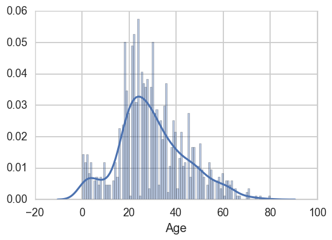

```python
# varible distributions
print total.Age[:5]
print '----------------'
print '%s missing value' %sum(pd.isnull(total.Age))
sns.distplot(total.Age[pd.notnull(total.Age)],bins=100)
```

```python
print total.Cabin[:5]
print '----------------'
print '%s missing value' %sum(pd.isnull(total.Cabin))
```

```
0     NaN
1     C85
2     NaN
3    C123
4     NaN
Name: Cabin, dtype: object
----------------
1014 missing value
```

```python
print total.Embarked[:5]
print '----------------'
print '%s missing value' %sum(pd.isnull(total.Embarked))
emcounts = total.Embarked.value_counts()
emcounts
```

```
0    S
1    C
2    S
3    S
4    S
Name: Embarked, dtype: object
----------------
2 missing value
```

```
S    914
C    270
Q    123
Name: Embarked, dtype: int64
```

```
0     7.2500
1    71.2833
2     7.9250
3    53.1000
4     8.0500
Name: Fare, dtype: float64
----------------
1 missing value
```

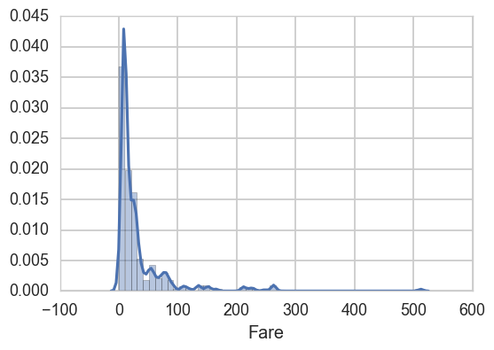

```python
print total.Fare[:5]
print '----------------'
print '%s missing value' %sum(pd.isnull(total.Fare))
sns.distplot(total.Fare[pd.notnull(total.Fare)])
```

```python
print total.Name[:5]
print '----------------'
print '%s missing value' %sum(pd.isnull(total.Name))
```

```
0                              Braund, Mr. Owen Harris
1    Cumings, Mrs. John Bradley (Florence Briggs Th...
2                               Heikkinen, Miss. Laina
3         Futrelle, Mrs. Jacques Heath (Lily May Peel)
4                             Allen, Mr. William Henry
Name: Name, dtype: object
----------------
0 missing value
```

```
0    0
1    0
2    0
3    0
4    0
Name: Parch, dtype: int64
----------------
0 missing value
```

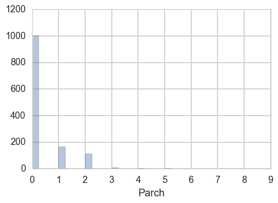

```python
print total.Parch[:5]
print '----------------'
print '%s missing value' %sum(pd.isnull(total.Parch))
sns.distplot(total.Parch[pd.notnull(total.Parch)],kde=False)
```

```python
total.PassengerId[:5]  # serise from 1:1039
```

```
0    1
1    2
2    3
3    4
4    5
Name: PassengerId, dtype: int64
```

```
0    3
1    1
2    3
3    1
4    3
Name: Pclass, dtype: int64
----------------
0 missing value
```

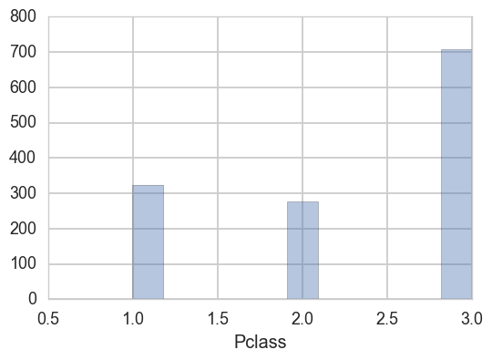

```python
print total.Pclass[:5]
print '----------------'
print '%s missing value' %sum(pd.isnull(total.Pclass))
sns.distplot(total.Pclass[pd.notnull(total.Pclass)],kde=False)
```

```python
print total.Sex[:5]
print '----------------'
print '%s missing value' %sum(pd.isnull(total.Sex))
sexcounts = total.Sex.value_counts()
sexcounts
```

```
0      male
1    female
2    female
3    female
4      male
Name: Sex, dtype: object
----------------
0 missing value
```

```
male      843
female    466
Name: Sex, dtype: int64
```

```
0    1
1    1
2    0
3    1
4    0
Name: SibSp, dtype: int64
----------------
0 missing value
```

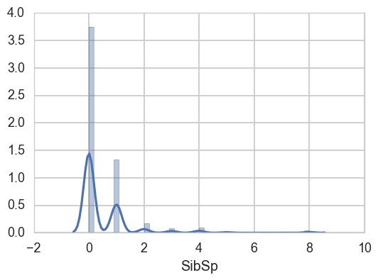

```python
print total.SibSp[:5]
print '----------------'
print '%s missing value' %sum(pd.isnull(total.SibSp))
sns.distplot(total.SibSp[pd.notnull(total.SibSp)])
```

```python
print train.Survived[:5]  # only train data has Survived varible
print '----------------'
print '%s missing value' %sum(pd.isnull(train.Survived))
train.Survived.value_counts()
```

```
0    0
1    1
2    1
3    1
4    0
Name: Survived, dtype: int64
----------------
0 missing value
```

```
0    549
1    342
Name: Survived, dtype: int64
```

```python
total.Ticket[:5]   # inregular format
```

```
0           A/5 21171
1            PC 17599
2    STON/O2. 3101282
3              113803
4              373450
Name: Ticket, dtype: object
```

## feature engineering

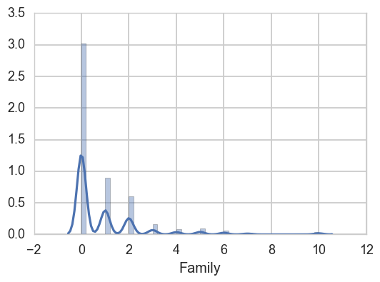

```python
## generate family varible with SibSp and Parch

total['Family'] = total.SibSp + total.Parch   # no missing values
sns.distplot(total.Family)
```

```python
## extract Title from Name valrible
import re

title = total.Name.apply(lambda x: "".join(re.findall(r"\,\ (.*)\.",x)))
title_counts = title.value_counts()
print title_counts
keep = title_counts[:4]
res = [x if x in keep else 'rare title' for x in title]
total['Title'] = res
print total.Title[:5]
total.Title.value_counts()
```

```
Mr                          757
Miss                        260
Mrs                         196
Master                       61
Rev                           8
Dr                            8
Col                           4
Major                         2
Mlle                          2
Ms                            2
Mme                           1
the Countess                  1
Don                           1
Lady                          1
Sir                           1
Jonkheer                      1
Dona                          1
Mrs. Martin (Elizabeth L      1
Capt                          1
Name: Name, dtype: int64
0      Mr
1     Mrs
2    Miss
3     Mrs
4      Mr
Name: Title, dtype: object
```

```
Mr            757
Miss          260
Mrs           196
Master         61
rare title     35
Name: Title, dtype: int64
```

```python
# deal with the ticket, cabin features
ticket = total.Ticket.apply(lambda x: x.split(" "))
ticket_english = ["".join(x[:-1]) if len(x)>=2 else "noword" for x in ticket]
ticket_number = [x[-1] if len(x) >= 2 else x[0] for x in ticket]
ticket_number = [int(x) if x != "LINE" else 1000000 for x in ticket_number]
total['ticket_words'] = ticket_english
total['ticket_number'] = ticket_number
cabin_word = total.Cabin.apply(lambda x: re.findall(r"[A-Za-z]", x)[0] if pd.isnull(x)==0 else np.nan)
cabin_number = total.Cabin.apply(lambda x: int(re.findall(r"\d+", x)[0]) if (pd.isnull(x)==0 and re.findall(r"\d+", x)) else np.nan)
total['cabin_word'] = cabin_word
total['cabin_number'] = cabin_number
```

```python
total[['Ticket','ticket_words','ticket_number']][:5]
```

|  | Ticket | ticket_words | ticket_number |
| --- | --- | --- | --- |
| 0 | A/5 21171 | A/5 | 21171 |
| 1 | PC 17599 | PC | 17599 |
| 2 | STON/O2. 3101282 | STON/O2. | 3101282 |
| 3 | 113803 | noword | 113803 |
| 4 | 373450 | noword | 373450 |

```python
total[['Cabin','cabin_word','cabin_number']][:5]
```

|  | Cabin | cabin_word | cabin_number |
| --- | --- | --- | --- |
| 0 | NaN | NaN | NaN |
| 1 | C85 | C | 85.0 |
| 2 | NaN | NaN | NaN |
| 3 | C123 | C | 123.0 |
| 4 | NaN | NaN | NaN |

```python
total.to_csv("../data/total_V2.csv")
```

```python
total.columns
```

```
Index([u'Age', u'Cabin', u'Embarked', u'Fare', u'Name', u'Parch',
       u'PassengerId', u'Pclass', u'Sex', u'SibSp', u'Survived', u'Ticket',
       u'Family', u'Title', u'ticket_words', u'ticket_number', u'cabin_word',
       u'cabin_number'],
      dtype='object')
```

```python
import sklearn
from sklearn.preprocessing import LabelEncoder
lb = LabelEncoder()
total['Embarked'] = lb.fit_transform(total.Embarked)
total['Sex'] = lb.fit_transform(total.Sex)
total['Title'] = lb.fit_transform(total.Title)
```

```python
test = total[pd.notnull(total.Survived)][['Age','Embarked','Fare','Pclass','Sex','Family','Title','Survived']].dropna()
varibles = test.drop("Survived",1)
target = test.Survived
```

```python
from sklearn import linear_model
from sklearn.metrics import accuracy_score

logreg = linear_model.LogisticRegression()
logreg.fit(varibles[:600], target[:600])
pred = logreg.predict(varibles[600:])
acc = accuracy_score(pred, target[600:])
```

```python
print 'accuracy for a defult logistic regression is %.4f' %acc
```

```
accuracy for a defult logistic regression is 0.8070
```

```python
importance = zip(list(varibles.columns),logreg.coef_[0])
importance = [[x[0],abs(x[1])] for x in importance]
importance = sorted(importance, key = lambda x: x[1], reverse=True)
importance
```

```
[['Sex', 2.3398517726416768],
 ['Pclass', 0.85577807746608925],
 ['Family', 0.20571612562970371],
 ['Embarked', 0.038391559157818909],
 ['Age', 0.025928943510067162],
 ['Title', 0.013105384003354462],
 ['Fare', 0.0046300396693659878]]
```